# Estudis d'Informàtica, Multimedia i Telecomunicacions

Pel que fa a la resta d’atributs no s’hi veuen patrons clars.

```r
# Atribut 'amount'
data$amount_cat <- cut(data$amount,
                       breaks = c(0, 1366, 2320, 3972, 18424),
                       labels = c("0-1366", "1366-2320", "2321-3972", "3973-18424"),
                       include.lowest = TRUE)
# Atribut 'age'
data$age_cat <- cut(data$age,
                    breaks = c(0, 27, 33, 42, 75),
                    labels = c("0-27", "28-33", "34-42", "43-75"),
                    include.lowest = TRUE)
```

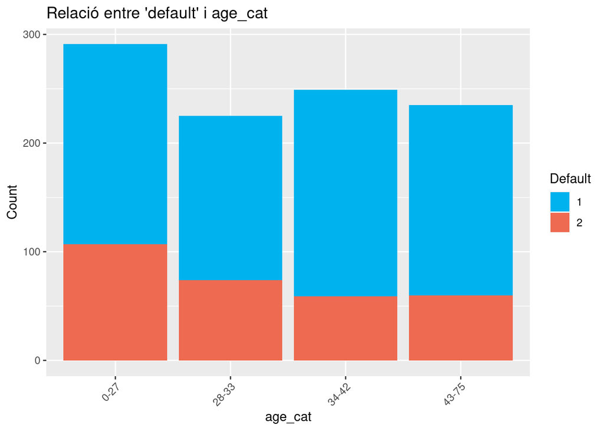

```r
# Funció per crear gràfics de barres apilats
barres_apilats <- function(variable_name) {
  ggplot(data, aes_string(x = variable_name, fill = "default")) +
    geom_bar(position = "stack") +
    scale_fill_manual(values = c("1" = "deepskyblue2", "2" = "coral2")) +
    labs(title = paste("Relació entre 'default' i", variable_name),
         x = variable_name, y = "Count", fill = "Default") +
    theme(axis.text.x = element_text(angle = 45, hjust = 1))
}

# Gràfics
barres_apilats("age_cat")
```

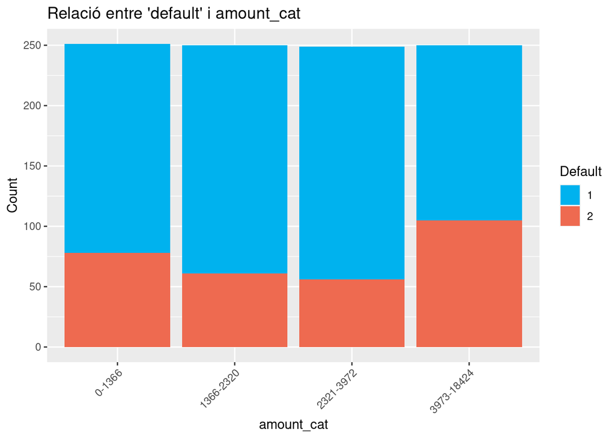

```r
barres_apilats("amount_cat")
```

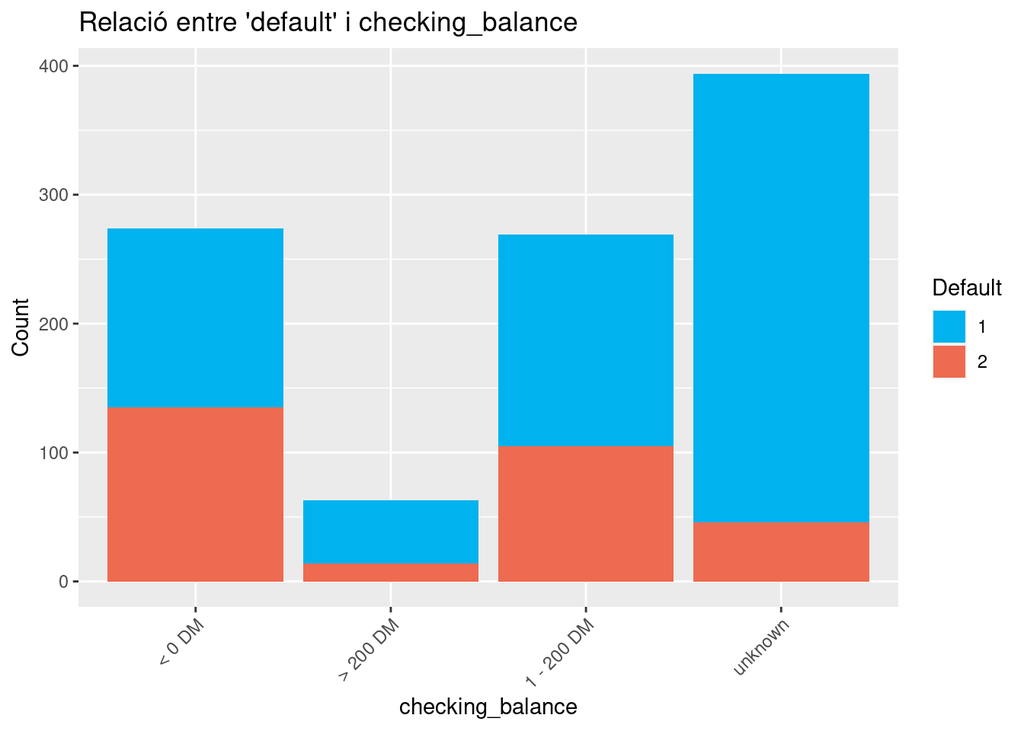

```r
barres_apilats("checking_balance")
```

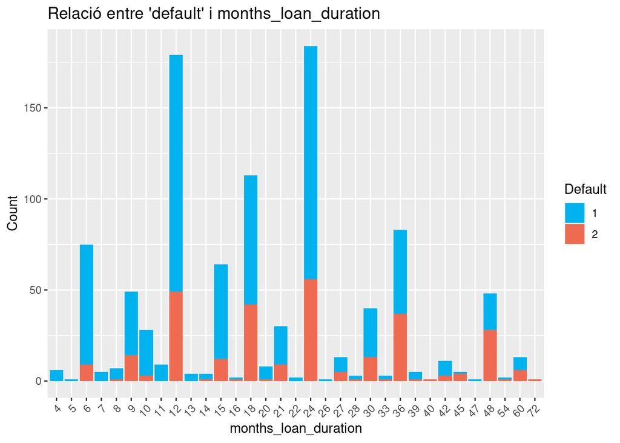

```r
barres_apilats("months_loan_duration")
```

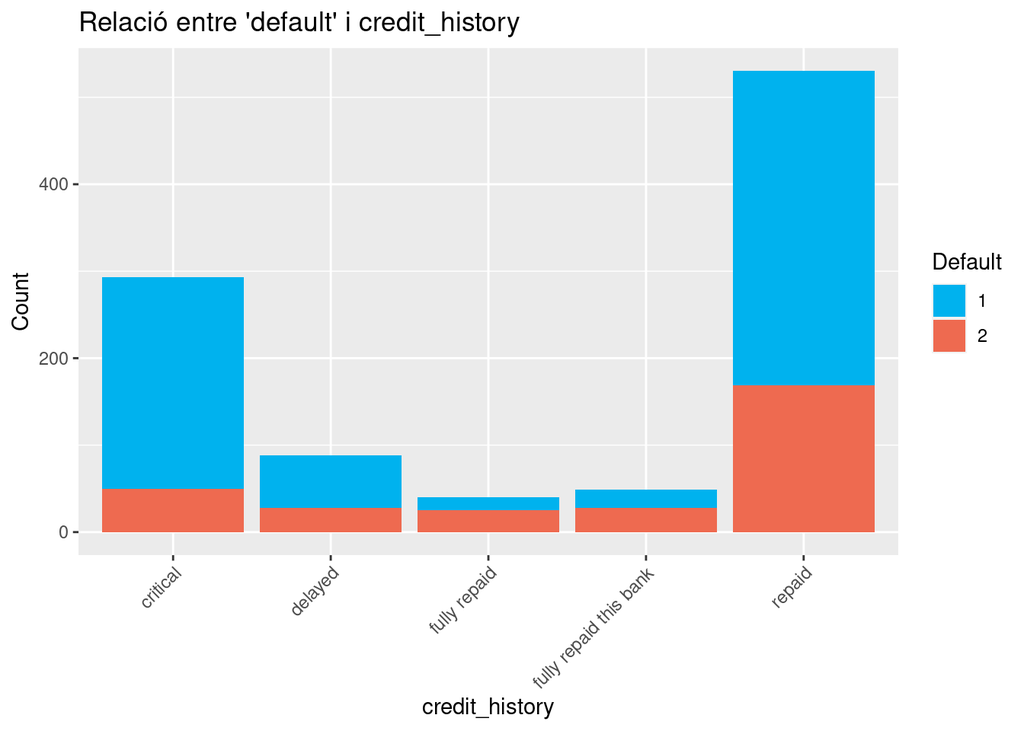

```r
barres_apilats("credit_history")
```

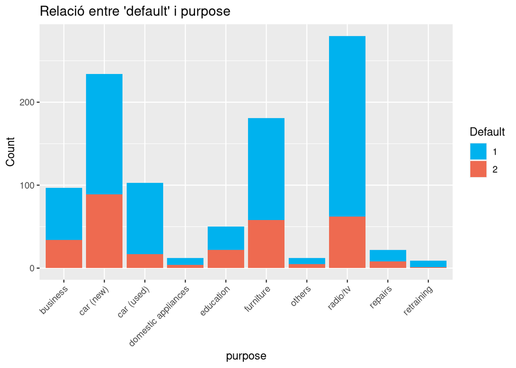

```r
barres_apilats("purpose")
```

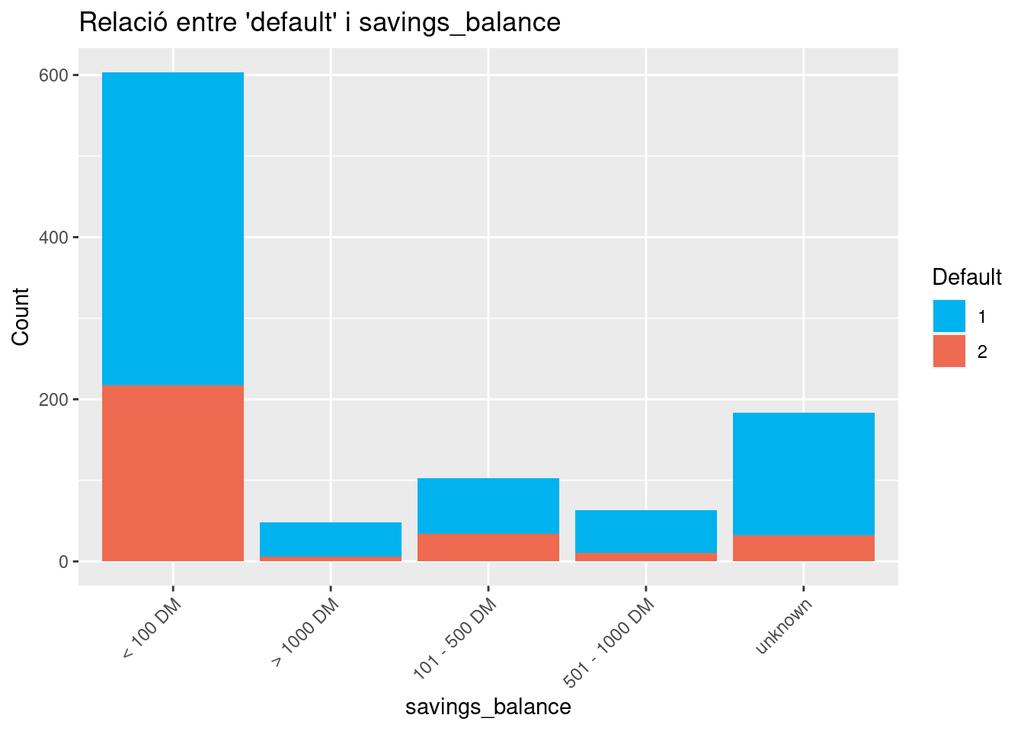

```r
barres_apilats("savings_balance")
```

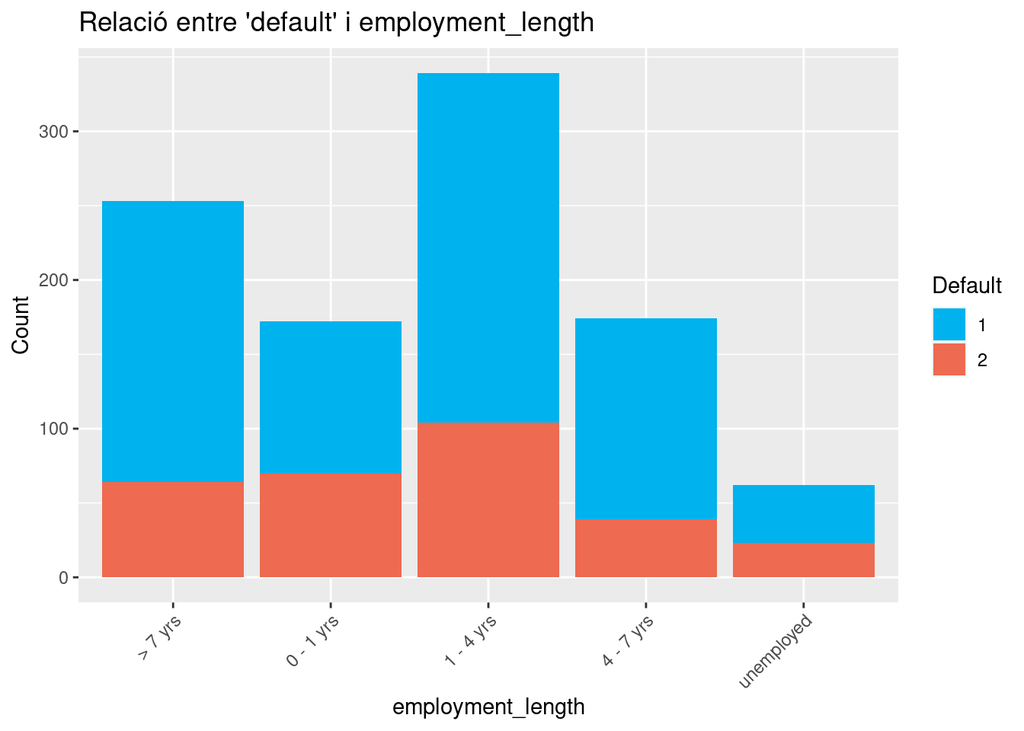

```r
barres_apilats("employment_length")
```

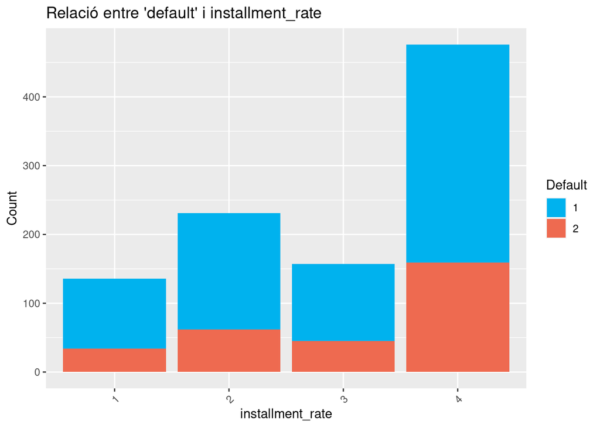

```r
barres_apilats("installment_rate")
```

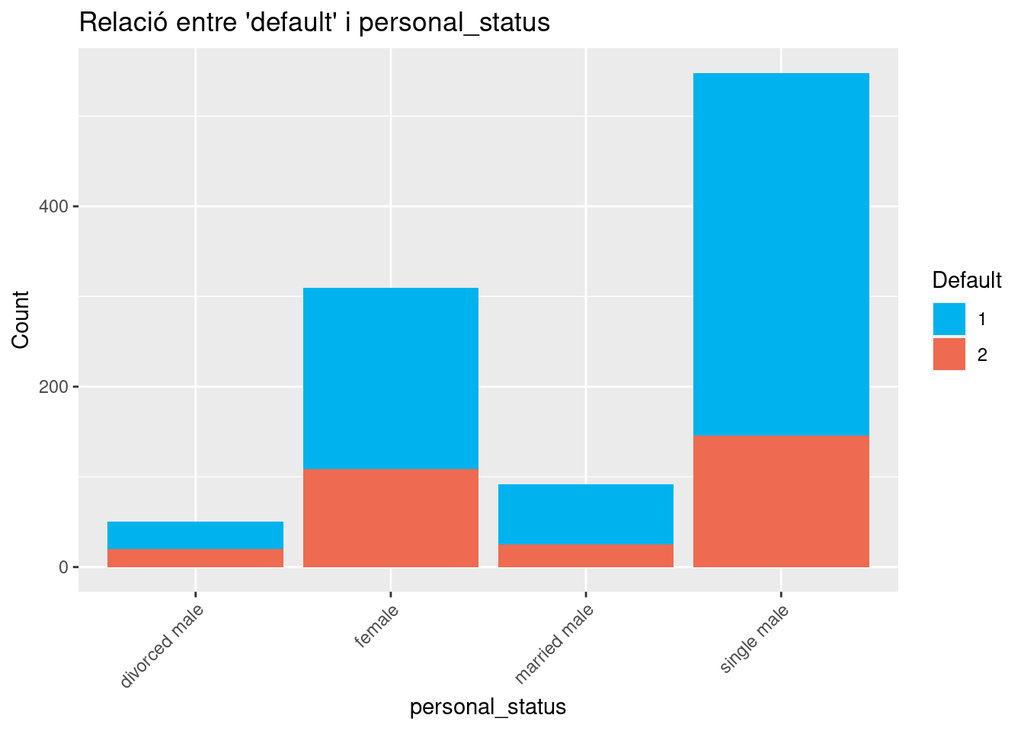

```r
barres_apilats("personal_status")
```

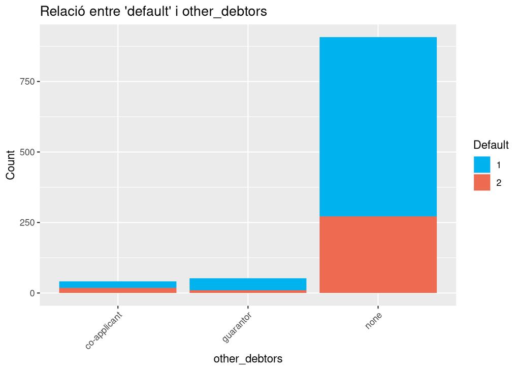

```r
barres_apilats("other_debtors")
```

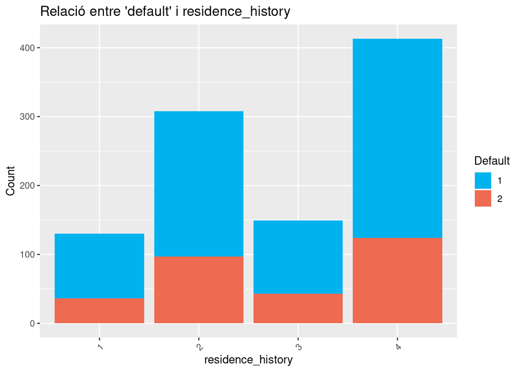

```r
barres_apilats("residence_history")
```

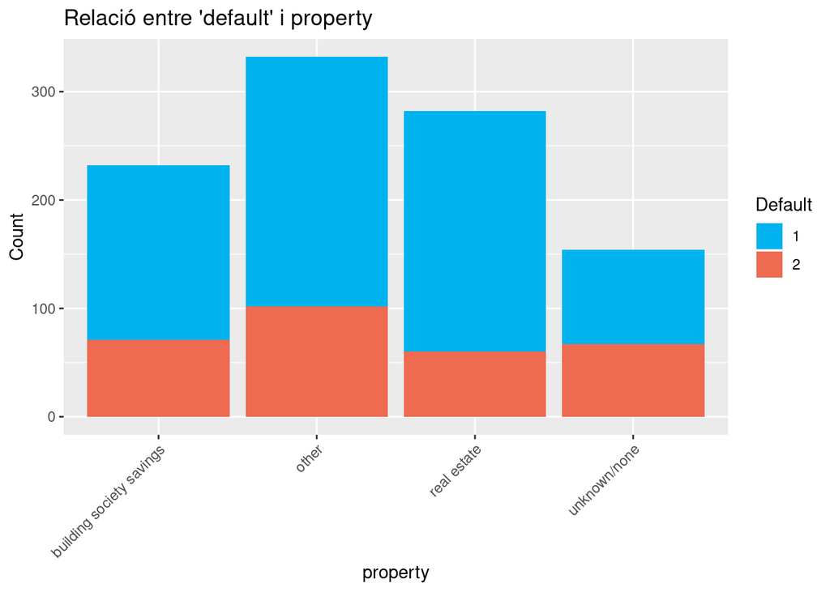

```r
barres_apilats("property")
```

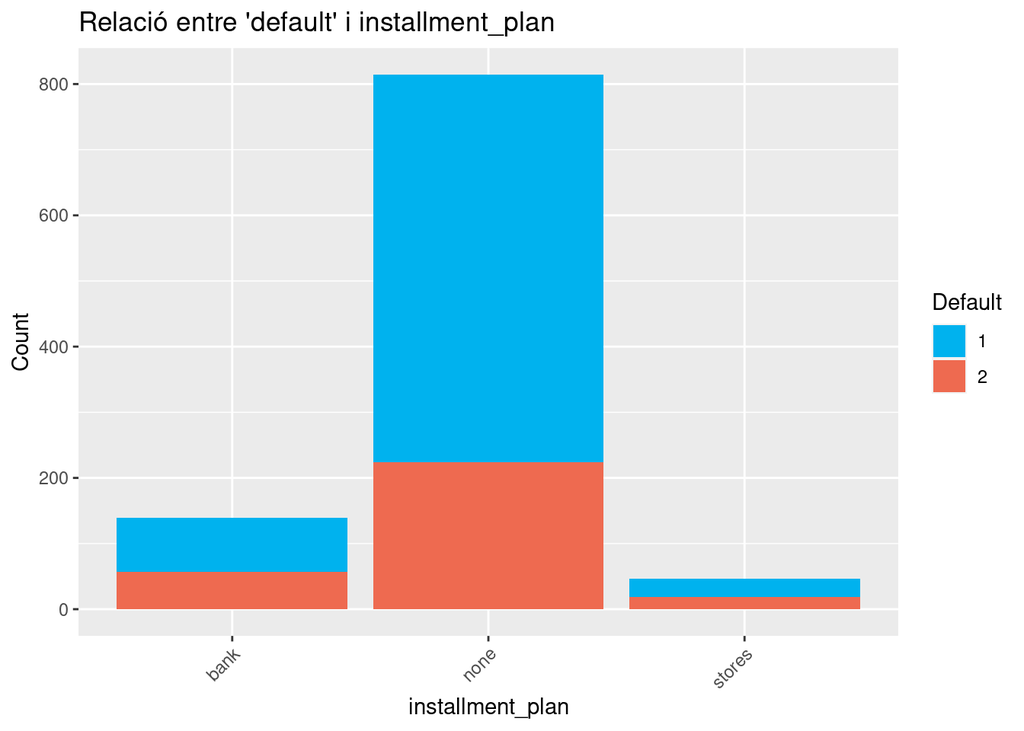

```r
barres_apilats("installment_plan")
```

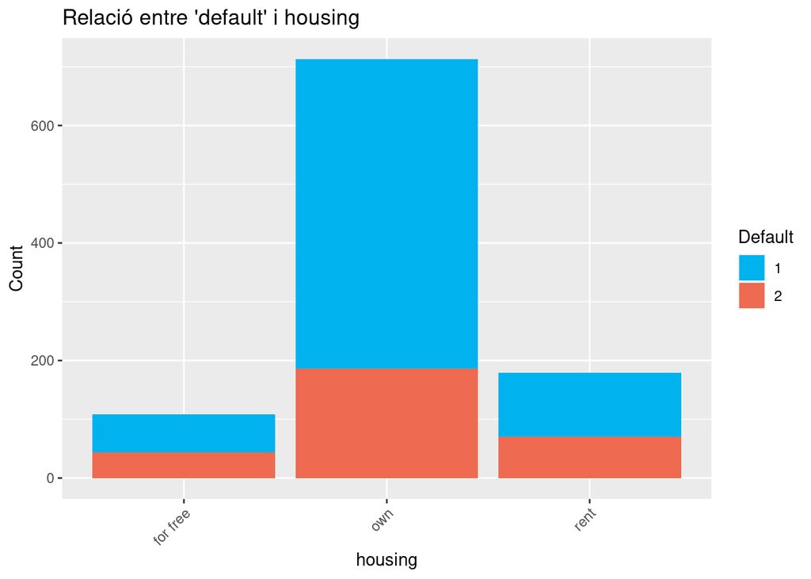

```r
barres_apilats("housing")
```

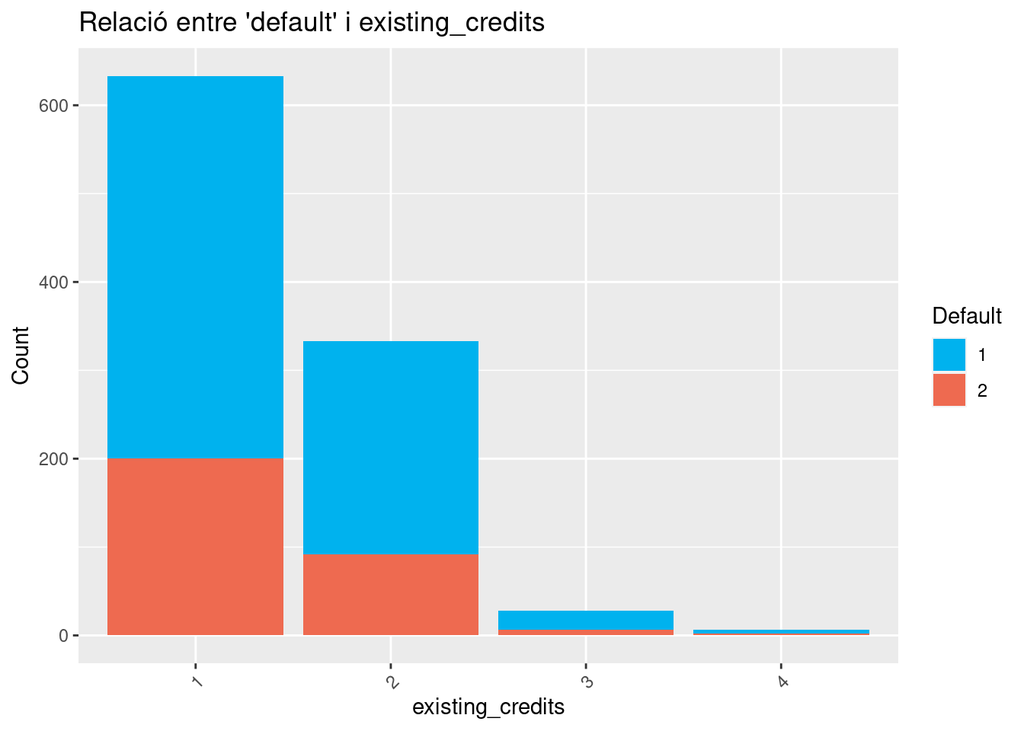

```r
barres_apilats("existing_credits")
```

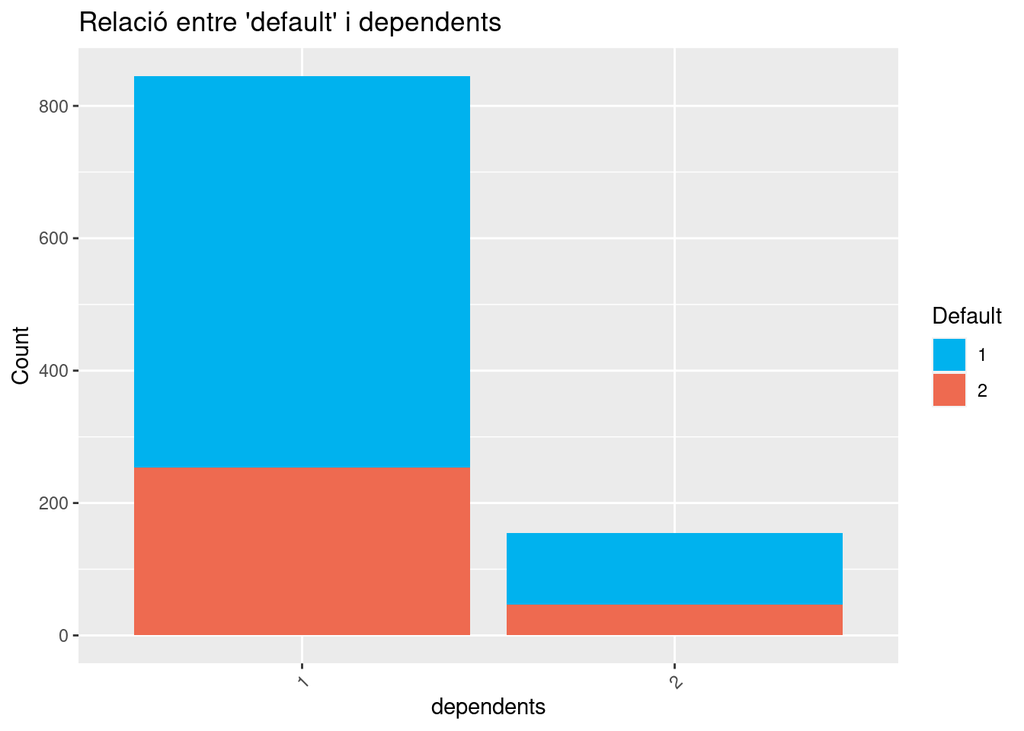

```r
barres_apilats("dependents")
```

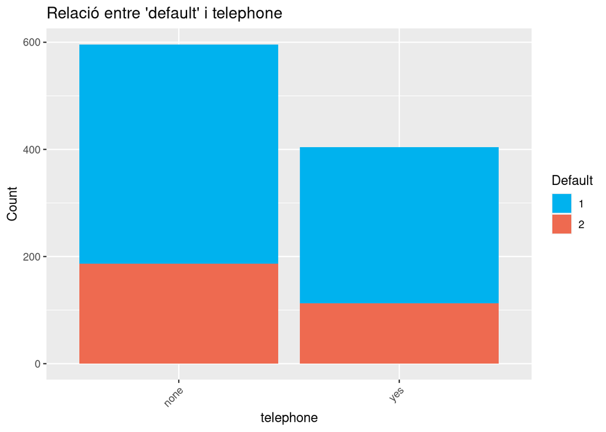

```r
barres_apilats("telephone")
```

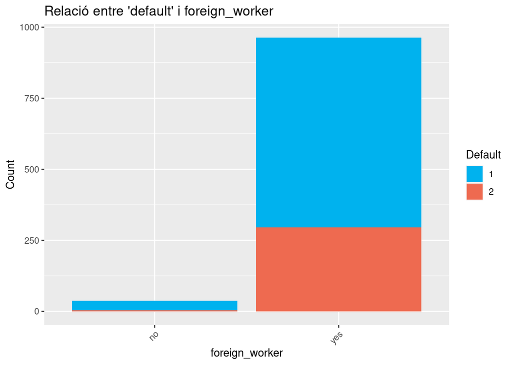

```r
barres_apilats("foreign_worker")
```

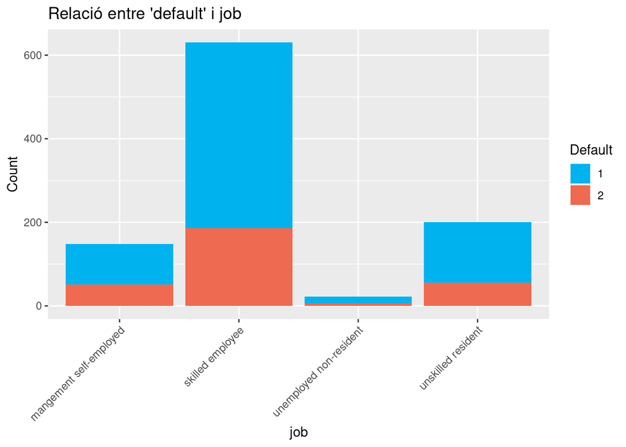

```r
barres_apilats("job")
```

```r
variables <- c("age_cat", "amount_cat", "checking_balance", "months_loan_duration",
               "credit_history", "purpose", "savings_balance", "employment_length",
               "installment_rate", "personal_status", "other_debtors", "residence_history",
               "property", "installment_plan", "housing", "existing_credits",
               "dependents", "telephone", "foreign_worker", "job")

for (var in variables) {
  # Crea la taula de contingència
  taula_temp <- table(data[[var]], data$default)

  # Mostra el nom de la variable i la taula
  cat("\nTaula de contingència per a", var, "i default:\n")
  print(taula_temp)
}
```

```
##
## Taula de contingència per a age_cat i default:
##
##           1   2
##   0-27  184 107
##   28-33 151  74
##   34-42 190  59
##   43-75 175  60
##
## Taula de contingència per a amount_cat i default:
##
##                1   2
##   0-1366     173  78
##   1366-2320  189  61
##   2321-3972  193  56
##   3973-18424 145 105
##
## Taula de contingència per a checking_balance i default:
##
##                1   2
##   < 0 DM     139 135
##   > 200 DM    49  14
##   1 - 200 DM 164 105
##   unknown    348  46
##
## Taula de contingència per a months_loan_duration i default:
##
##        1   2
##   4    6   0
##   5    1   0
##   6   66   9
##   7    5   0
##   8    6   1
##   9   35  14
##   10  25   3
##   11   9   0
##   12 130  49
##   13   4   0
##   14   3   1
##   15  52  12
```

[output cut: 134 more lines]

```
##   yes  291 113
##
## Taula de contingència per a foreign_worker i default:
##
##         1   2
##   no   33   4
##   yes 667 296
##
## Taula de contingència per a job i default:
##
##                             1   2
##   mangement self-employed  97  51
##   skilled employee        444 186
##   unemployed non-resident  15   7
##   unskilled resident      144  56
```

# 3 Desenvolupament d’un primer arbre de decisió

Per a poder avaluar del model és necessari tindre un conjunt de training i un de testing. El primer serà el sub-conjunt del conjunt de dades fet servir per a l’obtenció del model. El conjunt de testing són les dades (no vistes pel model durant l’entrenament) que es fan servir per avaluar la qualitat del model.

## 3.1 Conjunts d’entrenament i testing

Destinarem el 66% de les mostres a training i el 33% a testing. A més, guardarem una seed per a poder reproduïr l’estudi en cas que sigui necessari. Per facilitar el procediment, mourem la columna ‘default’, la nostre variable objectiu, a la última posició de ‘data’. També aprofitarem per eliminar ‘age’ i ‘amount’, ja que les hem discretitzat.

```r
default_col <- data$default
data <- data[, !(names(data) %in% c("default"))]
data <- data[, !(names(data) %in% c("age"))]
data <- data[, !(names(data) %in% c("amount"))]
data$default <- default_col
```

```r
set.seed(666)
y <- data[,21]
X <- data[,1:20]
```

De manera dinàmica podem definir una manera de separar les dades en funció d’un paràmetre, en aquest cas del “split_prop”. Definim un paràmetre que controla el split de manera dinàmica en el test.

```r
split_prop <- 3
indexes = sample(1:nrow(data), size=floor(((split_prop-1)/split_prop)*nrow(data)))
trainX<-X[indexes,]
trainy<-y[indexes]
testX<-X[-indexes,]
testy<-y[-indexes]
```

Ara és un bon moment per veure un resum dels conjunts de test i train per veure que tot ha sortit correctament i que la proporció de defaults és la mateixa que al joc de dades original.

```r
summary(trainX);
```

```
##    checking_balance months_loan_duration                credit_history
##  < 0 DM    :182     24     :122          critical              :190
##  > 200 DM  : 42     12     :115          delayed               : 60
##  1 - 200 DM:189     18     : 85          fully repaid          : 26
##  unknown   :253     36     : 60          fully repaid this bank: 33
##                     6      : 43          repaid                :357
##                     15     : 38
##                     (Other):203
##        purpose         savings_balance  employment_length installment_rate
##  radio/tv  :181   < 100 DM     :406    > 7 yrs   :162     1: 99
##  car (new) :155   > 1000 DM    : 32    0 - 1 yrs :110     2:151
##  furniture :128   101 - 500 DM : 65    1 - 4 yrs :230     3:102
##  car (used): 68   501 - 1000 DM: 37    4 - 7 yrs :120     4:314
##  business  : 66   unknown      :126    unemployed: 44
##  education : 32
##  (Other)   : 36
##       personal_status      other_debtors residence_history
##  divorced male: 34    co-applicant: 33   1: 83
##  female       :207    guarantor   : 31   2:203
##  married male : 56    none        :602   3: 96
##  single male  :369                       4:284
##
##
##
##                      property   installment_plan     housing
##  building society savings:148   bank  : 86       for free: 73
##  other                   :220   none  :551       own     :475
##  real estate             :194   stores: 29       rent    :118
##  unknown/none            :104
##
##
##
##  existing_credits dependents telephone  foreign_worker
##  1:420            1:569      none:394   no : 22
##  2:225            2: 97      yes :272   yes:644
##  3: 16
##  4:  5
##
##
##
##                       job           amount_cat   age_cat
##  mangement self-employed:103   0-1366    :158   0-27 :187
##  skilled employee       :428   1366-2320 :171   28-33:163
##  unemployed non-resident: 16   2321-3972 :167   34-42:171
##  unskilled resident     :119   3973-18424:170   43-75:145
##
##
##
```

```r
summary(trainy);
```

```
##   1   2
## 466 200
```

```r
summary(testX);
```

```
##    checking_balance months_loan_duration                credit_history
##  < 0 DM    : 92     12     :64           critical              :103
##  > 200 DM  : 21     24     :62           delayed               : 28
##  1 - 200 DM: 80     6      :32           fully repaid          : 14
##  unknown   :141     18     :28           fully repaid this bank: 16
##                     15     :26           repaid                :173
##                     36     :23
##                     (Other):99
##        purpose        savings_balance  employment_length installment_rate
##  radio/tv  :99   < 100 DM     :197    > 7 yrs   : 91     1: 37
##  car (new) :79   > 1000 DM    : 16    0 - 1 yrs : 62     2: 80
##  furniture :53   101 - 500 DM : 38    1 - 4 yrs :109     3: 55
##  car (used):35   501 - 1000 DM: 26    4 - 7 yrs : 54     4:162
##  business  :31   unknown      : 57    unemployed: 18
##  education :18
##  (Other)   :19
##       personal_status      other_debtors residence_history
##  divorced male: 16    co-applicant:  8   1: 47
##  female       :103    guarantor   : 21   2:105
##  married male : 36    none        :305   3: 53
##  single male  :179                       4:129
##
##
##
##                      property   installment_plan     housing
##  building society savings: 84   bank  : 53       for free: 35
##  other                   :112   none  :263       own     :238
##  real estate             : 88   stores: 18       rent    : 61
##  unknown/none            : 50
##
##
##
##  existing_credits dependents telephone  foreign_worker
##  1:213            1:276      none:202   no : 15
##  2:108            2: 58      yes :132   yes:319
##  3: 12
##  4:  1
##
##
##
##                       job           amount_cat  age_cat
##  mangement self-employed: 45   0-1366    :93   0-27 :104
##  skilled employee       :202   1366-2320 :79   28-33: 62
##  unemployed non-resident:  6   2321-3972 :82   34-42: 78
##  unskilled resident     : 81   3973-18424:80   43-75: 90
##
##
##
```

```r
summary(testy);
```

```
##   1   2
## 234 100
```

Observem hi ha més casos de default = 1 que de default = 2 tant en entrenament com en testing, però aquesta proporció també hi és en el joc de dades original. A més, la proporcio és de aproximadament 2.3 vegades default = 1 sobre default = 2 en els dos conjunts.

## 3.2 Creació del model, qualitat del model i extracció de regles

```r
trainy = as.factor(trainy)
model <- C50::C5.0(trainX, trainy,rules=TRUE )
summary(model)
```

```
##
## Call:
## C5.0.default(x = trainX, y = trainy, rules = TRUE)
##
##
## C5.0 [Release 2.07 GPL Edition]      Thu Dec 14 12:55:08 2023
## -------------------------------
##
## Class specified by attribute `outcome'
##
## Read 666 cases (21 attributes) from undefined.data
##
## Rules:
##
## Rule 1: (19/1, lift 1.3)
##  months_loan_duration = 24
##  property = unknown/none
##  job in {mangement self-employed, skilled employee,
##                 unemployed non-resident}
##  amount_cat in {1366-2320, 2321-3972, 3973-18424}
##  ->  class 1  [0.905]
##
## Rule 2: (6, lift 1.3)
##  purpose = furniture
##  installment_plan = stores
##  ->  class 1  [0.875]
##
## Rule 3: (253/36, lift 1.2)
##  checking_balance = unknown
##  ->  class 1  [0.855]
##
## Rule 4: (562/151, lift 1.0)
##  property in {building society savings, other, real estate}
##  ->  class 1  [0.730]
##
## Rule 5: (11, lift 3.1)
##  months_loan_duration = 48
##  savings_balance = < 100 DM
##  property in {building society savings, other, real estate}
##  ->  class 2  [0.923]
```

[output cut: 116 more lines]

```
##    5.26% amount_cat
##    4.50% credit_history
##    4.50% employment_length
##    3.15% savings_balance
##    2.85% job
##    2.25% purpose
##    2.10% installment_rate
##    1.50% other_debtors
##    1.35% installment_plan
##    0.60% age_cat
##    0.45% existing_credits
##    0.45% dependents
##
##
## Time: 0.0 secs
```

Abans de mostrar l’arbre obtingut, eliminarem les dades menys representatives, ja que en cas contrari, l’arbre tindrà moltes branques. Per tant, repetirem el procés que hem dut a terme per al nou dataframe.

```r
data_clean <- data[, !(names(data) %in% c("savings_balance", "job", "purpose",
                                          "installment_rate", "other_debtors",
                                          "installment_plan", "age_cat",
                                          "existing_credits", "dependents"))]

set.seed(666)
y <- data_clean[,12]
X <- data_clean[,1:11]

split_prop <- 3
indexes = sample(1:nrow(data), size=floor(((split_prop-1)/split_prop)*nrow(data)))
train_cleanX<-X[indexes,]
train_cleany<-y[indexes]
test_cleanX<-X[-indexes,]
test_cleany<-y[-indexes]

trainy = as.factor(train_cleany)
model_clean <- C50::C5.0(train_cleanX, train_cleany,rules=TRUE )
summary(model_clean)
```

```
##
## Call:
## C5.0.default(x = train_cleanX, y = train_cleany, rules = TRUE)
##
##
## C5.0 [Release 2.07 GPL Edition]      Thu Dec 14 12:55:08 2023
## -------------------------------
##
## Class specified by attribute `outcome'
##
## Read 666 cases (12 attributes) from undefined.data
##
## Rules:
##
## Rule 1: (18, lift 1.4)
##  months_loan_duration = 24
##  credit_history in {critical, delayed, repaid}
##  property = unknown/none
##  amount_cat in {1366-2320, 2321-3972, 3973-18424}
##  ->  class 1  [0.950]
##
## Rule 2: (253/36, lift 1.2)
##  checking_balance = unknown
##  ->  class 1  [0.855]
##
## Rule 3: (562/151, lift 1.0)
##  property in {building society savings, other, real estate}
##  ->  class 1  [0.730]
##
## Rule 4: (7, lift 3.0)
##  checking_balance in {< 0 DM, 1 - 200 DM}
##  months_loan_duration = 12
##  property = other
##  telephone = none
##  amount_cat = 0-1366
##  ->  class 2  [0.889]
##
## Rule 5: (11/1, lift 2.8)
##  checking_balance in {< 0 DM, > 200 DM, 1 - 200 DM}
##  months_loan_duration = 18
```

[output cut: 84 more lines]

```
##
##  Attribute usage:
##
##  100.00% checking_balance
##   87.09% property
##   17.87% months_loan_duration
##    7.36% credit_history
##    5.26% employment_length
##    5.11% amount_cat
##    4.05% telephone
##    3.60% foreign_worker
##    2.10% residence_history
##
##
## Time: 0.0 secs
```

[figure not shown]

```r
library(grid)
model_clean <- C50::C5.0(train_cleanX, train_cleany)
plot(model_clean,gp = gpar(fontsize = 6))
```

Tot i haver fet aquestes simplificacions, podem veure que l’arbre té moltes branques per a ser visualitzat. Una opció podria ser guardar la imatge a part per a estudiar-la més en profunditat. De totes maneres, la informació que voliem ja la tenim així que seguirem endavant amb la validació del model. Seguirem amb el model original, al que no li hem tret dades.

## 3.3 Validació del model amb les dades de testing

```r
predicted_model <- predict( model, testX, type="class" )
print(sprintf("La precisió de l'árbre és: %.4f %%",100*sum(predicted_model == testy) / length(predicted_model)))
```

```
## [1] "La precisió de l'árbre és: 75.1497 %"
```

A més, sempre és útil fer servir la matriu de confusió per veure els falsos postius, falsos negatius, verdaders positius i verdaders negatius. La matriu mostra els següents resultats:

- True Positives (TP): El model ha predit correctament la classe 1. Aquí, 212 és el nombre de TP.
- False Positives (FP): El model ha predit incorrectament la classe 1 quan en realitat era la classe 2. Aquí, 61 és el nombre de FP.
- False Negatives (FN): El model ha predit incorrectament la classe 2 quan en realitat era la classe 1. Aquí, 22 és el nombre de FN.
- True Negatives (TN): El model ha predit correctament la classe 2. Aquí, 39 és el nombre de TN.

Podem veure com podem calcular la precisió del model a partir de la matriu de confusió, ja que la presició es pot calcular com:

$\frac{(TP+TN)}{TP+TN+FP+FN}=\frac{212+39}{212+39+61+22}=0.75149$

```r
mat_conf<-table(testy,Predicted=predicted_model)
mat_conf
```

```
##      Predicted
## testy   1   2
##     1 212  22
##     2  61  39
```

Una altre forma de fer-ho és amb el paquet ‘gmodels’. Obtenim d’aquesta manera la matriu de confusió, la diferència és que en aquest cas es mostra la proporció de la cel·la respecte al total d’observacions. Gràcies a aquesta informació no només podem veure el nombre de prediccions correctes i incorrectes sinó també com es distribueixen aquestes prediccions entre les diferents categories. Aquesta informació pot donar una visió més clara de l’impacte de cada tipus de predicció respecte al total, cosa que és essencial per a avaluar la sensibilitat del model per identificar correctament les diferents categories de la variable objectiu.

```r
library(gmodels)
```

```r
CrossTable(testy, predicted_model,prop.chisq  = FALSE, prop.c = FALSE, prop.r =FALSE,dnn = c('Reality', 'Prediction'))
```

```
##
##
##    Cell Contents
## |-------------------------|
## |                       N |
## |         N / Table Total |
## |-------------------------|
##
##
## Total Observations in Table:  334
##
##
##              | Prediction
##      Reality |         1 |         2 | Row Total |
## -------------|-----------|-----------|-----------|
##            1 |       212 |        22 |       234 |
##              |     0.635 |     0.066 |           |
## -------------|-----------|-----------|-----------|
##            2 |        61 |        39 |       100 |
##              |     0.183 |     0.117 |           |
## -------------|-----------|-----------|-----------|
## Column Total |       273 |        61 |       334 |
## -------------|-----------|-----------|-----------|
##
##
```

Amb tots els resultats obtinguts fins ara podem treure les següents conclusions:

- *Precisió General:* Una precisió del ~75% ens indica que aproximadament tres de cada quatre prediccions són correctes. Depèn de la funció del model podria ser un bon resultat però tenint en compte que es vol utilitzar per a fer prediccions sobre donar o no prèstecs, la precisió hauria de ser més alta. Altres exemples on una precisió més alta seria recomenable seria per a aplicacions mèdiques o de seguretat.
- *Sensibilitat respecte a la default = 1:* La sensibilitat d’aquesta classe és de $212/234=0.906$, és a dir més o menys del 90%. Això vol dir que el model és bo alhora de detectar aquesta classe.
- *Sensibilitat respecte a la default = 2:* En canvi, en aquest cas el model no és tan bo, ja que si fem els càlculs obtenim $39/100=0.39$, és a dir, un 39%.

# 4 Modificació de l’enfocament original

Per a intentar millorar el model farem un Random Forest, fent servir la llibreria *randomForest* de R. Aquest és un mètode basat en la combinació de múltiples arbres de decisió per a millorar la robustesa i la presició de la predicció del model. Primer carregarem la llibreria necessària i entrenarem el model.

```r
library(randomForest)
# Entrenament del model
model_randomForest <- randomForest(x = trainX, y = trainy)
```

Amb l’entrenament realitzat és el moment de evaluar el nou model obtingut i veure si hi ha hagut una millora respecte al primer.

```r
predicted_model_randomForest <- predict(model_randomForest, testX, type="class")
print(sprintf("La precisió de l'árbre és: %.4f %%",100*sum(predicted_model_randomForest == testy) / length(predicted_model_randomForest)))
```

```
## [1] "La precisió de l'árbre és: 77.2455 %"
```

Mirem també la matriu de confusió,

```r
CrossTable(testy, predicted_model_randomForest,prop.chisq  = FALSE, prop.c = FALSE, prop.r =FALSE,dnn = c('Reality', 'Prediction'))
```

```
##
##
##    Cell Contents
## |-------------------------|
## |                       N |
## |         N / Table Total |
## |-------------------------|
##
##
## Total Observations in Table:  334
##
##
##              | Prediction
##      Reality |         1 |         2 | Row Total |
## -------------|-----------|-----------|-----------|
##            1 |       217 |        17 |       234 |
##              |     0.650 |     0.051 |           |
## -------------|-----------|-----------|-----------|
##            2 |        59 |        41 |       100 |
##              |     0.177 |     0.123 |           |
## -------------|-----------|-----------|-----------|
## Column Total |       276 |        58 |       334 |
## -------------|-----------|-----------|-----------|
##
##
```

## 4.1 Modificació de paràmetres

Podem modificar certs paràmetres per a l’entrenament del model, l’experimentació ens donarà diferents models i es pot arribar a obtenir un model millor. L’ajust de hyper-paràmetres és procés molt utilitzat en entrenament de Machine Learning o Deep Learning on, amb una mateixa estructura de model però amb diferents valors d’aquest paràmetres es poden obtindre models molt millors.

En el nostre cas podem modificar el nombre d’arbres o la profunditat màxima dels arbres. A més, **randomForest** ens pot oferir informació sobre la importància de les diferents característiques en la preducció.

```r
importance(model_randomForest)
```

```
##                      MeanDecreaseGini
## checking_balance            23.882543
## months_loan_duration        50.685910
## credit_history              19.585076
## purpose                     25.399940
## savings_balance             14.182099
## employment_length           17.622723
## installment_rate            12.937973
## personal_status              9.802428
## other_debtors                4.172543
## residence_history           12.937708
## property                    15.183430
## installment_plan             7.841778
## housing                      6.789429
## existing_credits             6.509517
## dependents                   3.177098
## telephone                    4.952536
## foreign_worker               0.967522
## job                          9.519913
## amount_cat                  15.260972
## age_cat                     14.661243
```

El valor de **MeanDecreaseGini** representa com contribueix una variable a la homogeneïtat dels nodes dels arbres de decisió en el nostre bosc. Un valor alt implica que aquella variable és més important per a la classificació. És important remarcar que no són percentatges. Amb la informació obtinguda podem veure que les variables ‘months_loan_duration’, ‘purpose’, ‘checking_balance’, ‘credit_history’ i ‘employment_lenght’ són les que tenen els valors més alts i per tant, les més important per a les prediccions del model. És interessant veure que la importància de les variables en la predicció és diferent a la que haviem obtingut en apartats anteriors, on una de las variables més importants era ‘property’.

El següent pas en la millora del nostre model és la modificació dels paràmetres d’entrenament.Modificarem el nombre d’Arbres i farem servir ponderació de classes per donar representació per igual als dos casos.

- Nombre d’Arbres (ntree): Un nombre més alt d’arbres pot millorar la precisió, però també incrementerà el temps de càlcul i la memòria utilitzada. El valor per defecte es 500.

```r
set.seed(666)
model_randomForest <- randomForest(x = trainX, y = trainy, ntree = 1000)
predicted_model_randomForest <- predict(model_randomForest, testX, type="class")
print(sprintf("La precisió de l'árbre amb ntree = 1000 és: %.4f %%",100*sum(predicted_model_randomForest == testy) / length(predicted_model_randomForest)))
```

```
## [1] "La precisió de l'árbre amb ntree = 1000 és: 78.1437 %"
```

```r
set.seed(666)
model_randomForest <- randomForest(x = trainX, y = trainy, ntree = 50)
predicted_model_randomForest <- predict(model_randomForest, testX, type="class")
print(sprintf("La precisió de l'árbre amb ntree = 60 és: %.4f %%",100*sum(predicted_model_randomForest == testy) / length(predicted_model_randomForest)))
```

[output not shown]

Podem veure que en aquesta aplicació el nombre d’arbres no modifica molt la precisió del model, això és degut a que amb pocs arbres ja arribem al límit del model. Afegir-ne més no ens aportarà millores significatives (podria aportar fins i tot overfitting al model). Si fem un mostratge de l’hiperparàmetre ntree i en dibuixem la gràfica podem veure com, en aquesta aplicació, no es millora el model.

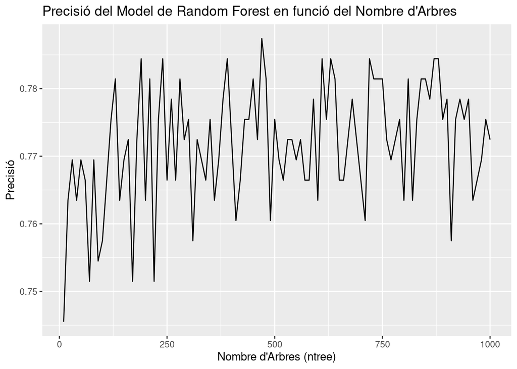

```r
set.seed(666)
valors_ntree <- seq(10, 1000, by = 10)
precisions <- numeric(length(valors_ntree))

for (i in seq_along(valors_ntree)) {
    model <- randomForest(x = trainX, y = trainy, ntree = valors_ntree[i])
    predictions <- predict(model, testX)
    precisions[i] <- sum(predictions == testy) / length(testy)
}

resultats <- data.frame(ntree = valors_ntree, accuracy = precisions)

ggplot(resultats, aes(x = ntree, y = accuracy)) +
    geom_line() +
    xlab("Nombre d'Arbres (ntree)") +
    ylab("Precisió") +
    ggtitle("Precisió del Model de Random Forest en funció del Nombre d'Arbres")
```

Podem veure com la precisió del model oscil·la entre el 75% i el 79% tenint un màxim al voltant dels 450 arbres.

```r
index_max_precisio <- which.max(resultats$accuracy)
max_precisio <- resultats$accuracy[index_max_precisio]
ntree_max_precisio <- resultats$ntree[index_max_precisio]
print(paste("La precisió màxima és", max_precisio, "amb", ntree_max_precisio, "arbres."))
```

```
## [1] "La precisió màxima és 0.787425149700599 amb 470 arbres."
```

- Ponderació de Classes (classwt): Com en el nostre joc de dades les classes estan desequilibrades, farem servir aquest paràmetre per donar més pes a la classe menys representada.

```r
set.seed(666)
class_weights <- c(1, 2)
model_randomForest <- randomForest(x = trainX, y = trainy, ntree = 470, classwt = class_weights)
predicted_model_randomForest <- predict(model_randomForest, testX, type="class")
print(sprintf("La precisió de l'árbre és: %.4f %%",100*sum(predicted_model_randomForest == testy) / length(predicted_model_randomForest)))
```

```
## [1] "La precisió de l'árbre és: 77.2455 %"
```

Donant el doble de pes a la segona classe, el model es manté pràcticament igual. Però podem observar com ara el nombre d’Arbres que hem calculat abans, ja no és el millor valor, ja que al modificar un altre hiperparàmetre el model és diferent.

```r
set.seed(666)
class_weights <- c(1, 2)
model_randomForest <- randomForest(x = trainX, y = trainy, ntree = 60, classwt = class_weights)
predicted_model_randomForest <- predict(model_randomForest, testX, type="class")
print(sprintf("La precisió de l'árbre és: %.4f %%",100*sum(predicted_model_randomForest == testy) / length(predicted_model_randomForest)))
```

```
## [1] "La precisió de l'árbre és: 78.4431 %"
```

Podem veure com buscar el millor valor d’un hiperparàmetre pot no ser bona idea, ja que al modificar-ne un altre, la feina que hem fet no servirà. És per això que la optimització de models mitjançant l’ajust de hiperparàmetres és una tasca molt complexa que moltes vegades requereix molt de prova i error.

# 5 Resum i conclusions

En aquesta pràctica hem vist com mitjançant l’ús d’arbres de decisió es poden obtindre models per a la classificació de dades. A més, hem vist la necessitat de dividir el joc de dades en subconjunts de testing i training, ja que si entrenem el model amb unes dades i l’avaluem amb les mateixes no podriem distingir el cas en el que del model ha après a classificar del que en el model ha memoritzat les dades.

La obtenció de models és una tasca complexa que requereix de moltes proves i anàlisi, a més, cada aplicació pot tindre paràmetres òptims diferents. Tot i això hem vist com hi ha tècniques que milloren un model, al comparar el model obtingut amb un únic arbre amb el model obtingut amb random Forest. Tot i que la millora del model no ha sigut significativa, no vol dir que en altres aplicacions no impliqui una millora important del model.

Els models obtinguts tenen tots una precisió semblant al voltant del 75% que no es un bon resultat per al tipus d’aplicació que volem. Es podrien millorar els resultats afegint més dades, per exemple fent servir tècniques de Data Augmentation, molt usades en el camps del Deep Learning. També es podria buscar un altre model entrenat amb altres dades i aplicar tècniques de transfer learning per a partir d’un model pre-entrenat i a partir de allà ajustar-lo a les nostres dades (en parlen al paper ‘Transfer Learning in Decision Trees’, https://ieeexplore.ieee.org/document/4371047).